# Using containers as development environments

CCBR Code Club

[Kelly Sovacool](https://github.com/kelly-sovacool)

Oct 07, 2026

## Installers & dependency managers

|  | language | environments |
| --- | --- | --- |
| pip | python | ❌ |
| uv, venv, pyenv | python | ✅ |
| `install.packages`, pak | R | ❌ |
| renv | R | ✅ |
| conda, mamba | polyglot | ✅ |
| pixi | polyglot | ✅ |

## Separate environments per project for reproducibility

```markdown
~/projects
├── CCBR-abc
├── CCBR-xyz
├── cool-python-package
└── RStatsPackage
```

## Separate environments per project for reproducibility

```markdown
~/projects
├── CCBR-abc
│   └── environment.yml
├── CCBR-xyz
│   ├── data-integration
│   │   └── env.yml
│   └── figures
│       └── env.yml
├── cool-python-package
│   └── pyproject.toml
└── RStatsPackage
    └── renv.lock
```

- Each project specifies its own package versions.
- Can use different environment managers for different projects.
- Keep configuration in git so it is version-controlled & shared with others.

## Containers handle dependencies at the OS level

### Package managers

**Install dependency versions on your local machine.**

There can be slight differences in compiled versions of software depending on the hardware and operating system.

### Containers

**Ship with exact versions of dependencies already compiled and installed for a specific OS.**

Extremely useful for pipelines; each step gets its own container. Users don’t have to worry about installing dependencies.

## Containers as development environments

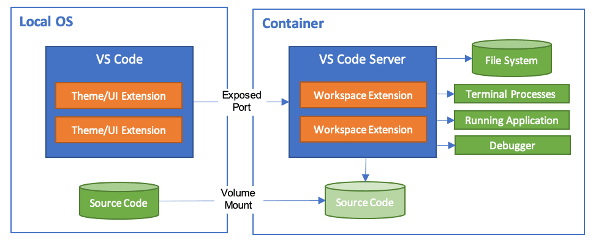

Architecture of Dev Containers. Source: https://code.visualstudio.com/docs/devcontainers/containers

## Why use Dev Containers?

- Dependency management for developers, including IDE extensions.
- Consistent dependency versions across collaborators.
- Keep genAI tools in a sandbox for security.

### Why *not*?

- Heavier disk usage.
- Building takes time.
- Not user-friendly.
- Not intended for *users*, only *contributors*.
  - Still need to have adequate documentation of dependencies for users.

## Container engines

[output not shown]

## How to use Dev Containers on macOS

1. Install podman.
2. Set up Dev Containers in VS Code.
3. Configure Dev Containers for your projects.

## Podman

[figure not shown]

Download Podman Desktop from [`podman.io`](https://podman.io)

## Podman

[figure not shown]

Install and open Podman Desktop

## Podman

[figure not shown]

Create new podman machine

## Podman

[figure not shown]

Increase the default resource allocation. Make sure it is rootless!

## Podman

[figure not shown]

Machine is now running

## Podman

[figure not shown]

Optional: auto-start the machine when podman starts

## Podman

[figure not shown]

Optional: start podman when you login. Consider toggling on if you use podman daily, or toggle it off if you use it sparingly.

## Podman CLI

Optional: you can configure the default machine and start it via the Podman CLI rather than the Desktop

```
Terminal
```

```bash
podman machine set --cpus 4 --disk-size 100 --memory 8192 --rootful=false
podman machine start
```

## VS Code

[figure not shown]

Install the Dev Containers extension

## VS Code

- Open VS Code settings
- Search for “Dev Containers” and scroll down to **Docker Compose** & **Docker Path**.
- Set **Docker Compose** to `podman-compose`
- Set **Docker Path** to full path to podman (`which podman` ➡️ `/opt/podman/bin/podman`)

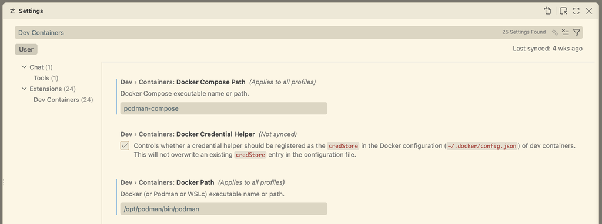

Change settings to use podman instead of docker

## Open a project in VS Code

`File` > `Open` or

[figure not shown]

## Create a basic Dev Container configuration file

```
.devcontainer/devcontainer.json
```

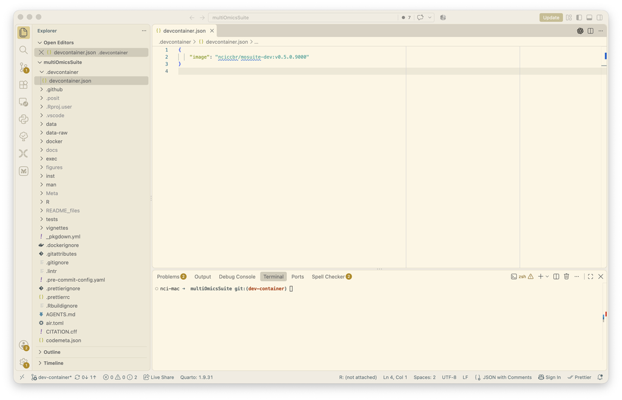

```json
{
    "image": "nciccbr/mosuite-dev:v0.5.0.9000"
}
```

## Start the Dev Container

- Open the VS Code command palette: `F1`
- Select **`Dev Containers: Reopen in Container`**

[figure not shown]

**Tip**

Disconnect from the VPN when pulling a base container for the first time – it may interfere with the download.

## Start the Dev Container

[figure not shown]

It will take some time to build the container the first time. After that it will cache the image and perform much faster.

## Start the Dev Container

[figure not shown]

- You’ll have all of the dependencies installed in the container available to use during development and testing.
- Podman mounts the project directory to the container, and those are the only files that can be edited in the VS Code session.

## Dev Container from local dockerfile

Container image from a registry:

```
devcontainer.json
```

```json
{
    "image": "nciccbr/mosuite-dev:v0.5.0.9000"
}
```

Container image built from a local file:

```
devcontainer.json
```

```json
{
  "build": {
    "dockerfile": "../docker/Dockerfile-dev",
    "context": ".."
  }
}
```

**Benefit of building from a local Dockerfile**: you can edit the Dockerfile and immediately use it to rebuild the Dev Container.

Using a pre-built image means if you edit the Dockerfile, you would first have to build and push a new image tag to a container registry, then rebuild the Dev Container from the new tag.

## Rebuild the container when the config changes

[figure not shown]

The extension detects when the config file changes and will prompt you to rebuild the container.

## Rebuild the container when the config changes

You can also trigger a rebuild via the command palette.

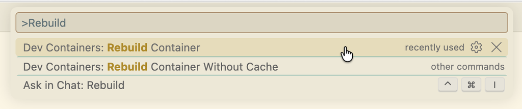

## GenAI in Dev Containers

##### Rootless containers can act as a sandbox to prevent agents from accessing files in other projects.

Copilot was unable to write to a file in another repo.

If it went rogue and tried to anyway, it would be *incapable* of doing so.

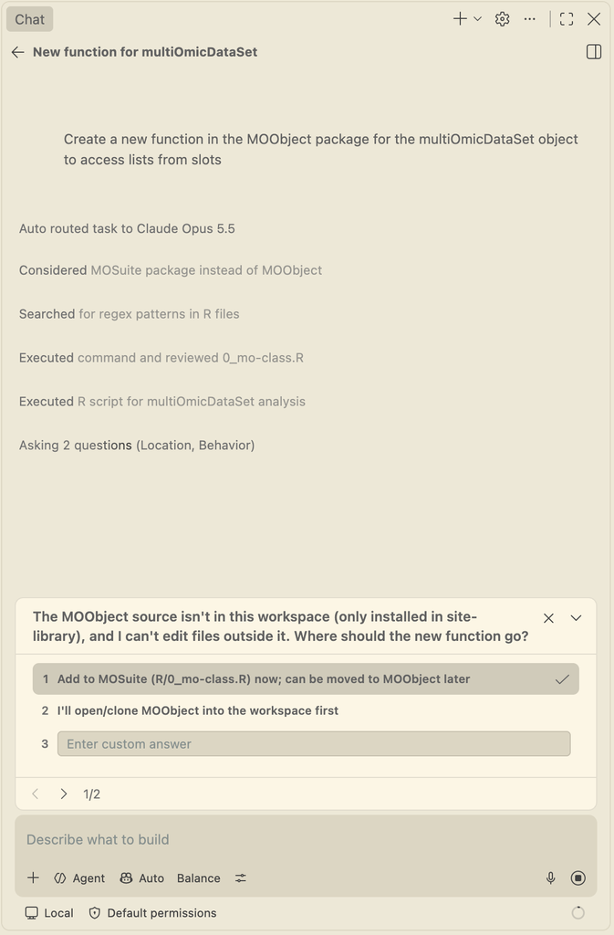

## Project organization

**Option 1**: One Dev Container per repository, open a separate VS Code window for each repo you’re working on.

```
VS Code window 1
```

```markdown
~/CCBR/mosuite
├── .devcontainer/
│   ├── devcontainer-lock.json
│   └── devcontainer.json
├── DESCRIPTION
├── docker/
│   ├── Dockerfile
│   └── Dockerfile-dev
├── R/
└── ...
```

```
VS Code window 2
```

```markdown
~/CCBR/Tools
├── .devcontainer/
│   ├── devcontainer-lock.json
│   └── devcontainer.json
├── docker/
│   ├── Dockerfile
│   └── Dockerfile-dev
├── pyproject.toml
├── src/
└── ...
```

**Tip**

This works best when the projects are mostly unrelated and not interdependent.

## Project organization

**Option 2**: Create a workspace with repos in subdirectories. Only need to open one VS Code window for the workspace.

```
VS Code workspace
```

```markdown
~/projects/NIDAP
├── .devcontainer/
│   ├── devcontainer-lock.json
│   └── devcontainer.json
├── Code-Ocean.code-workspace
├── Code-Ocean-Capsule-Template/
├── demo-syncweaver-host-capsule/
├── demo-syncweaver-source-monorepo/
├── MOSuite-batch-correct-counts/
├── MOSuite-clean/
├── MOSuite-create/
├── MOSuite-diff-counts/
├── MOSuite-filter-counts/
├── MOSuite-filter-diff/
├── MOSuite-normalize-counts/
├── OMIX/
└── ...
```

**Tip**

This option works best for projects with multiple related and interconnected repositories. If you often need to edit code across multiple repos for a given task, set up a workspace with all of those repos.

**Tip**

These 2 options are not mutually-exclusive. You can mix-and-match as you see fit!

## How to find examples of Dev Containers

Look for samples and template Dev Containers from established projects for inspiration.

- Official registry of Dev Container templates: https://containers.dev/templates
- rocker (R containers): https://rocker-project.org/images/devcontainer/templates.html
- VS Code sample Dev Containers

## Sample Dev Containers

Open the command palette (`F1`) and search for “sample”.

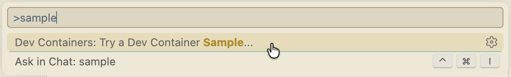

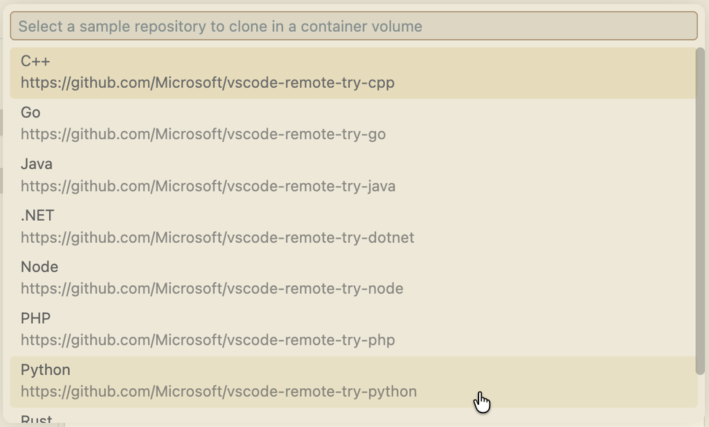

https://code.visualstudio.com/docs/devcontainers/tutorial#_get-the-sample

## Sample Dev Container: Python

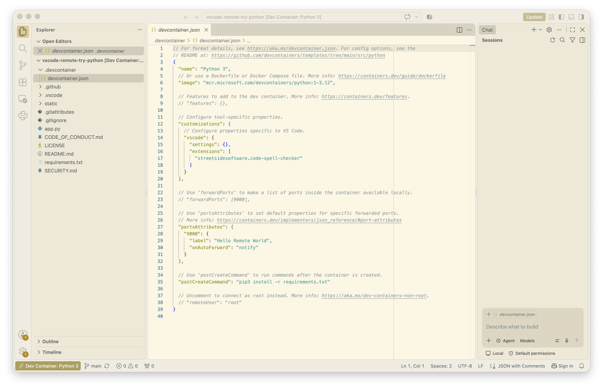

## Dev Container Features

> Development container “Features” are self-contained, shareable units of installation code and Dev Container configuration. The name comes from the idea that referencing one of them allows you to quickly and easily add more tooling, runtime, or library “Features” into your development container for use by you or your collaborators.

> *– [VS Code docs: Dev Container Features](https://code.visualstudio.com/docs/devcontainers/containers#_dev-container-features)*

Registry of Features: https://containers.dev/features

## Dev Container Features

```
devcontainer.json
```

```json
{
    "name": "Data Science (Python and R)",
    "image": "mcr.microsoft.com/devcontainers/base:ubuntu",
    // Features to add to the Dev Container. More info: https://containers.dev/features.
    "features": {
        "ghcr.io/devcontainers/features/python:1": {
            "version": "latest"
        },
        "ghcr.io/rocker-org/devcontainer-features/r-apt:latest": {
            "vscodeRSupport": "full",
            "installDevTools": true,
            "installRadian": true,
            "installRMarkdown": true,
            "installVscDebugger": true
        },
        "ghcr.io/rocker-org/devcontainer-features/apt-packages:1": {
            "packages": "r-cran-data.table,r-cran-tidyverse",
            "upgradePackages": true
        }
    },
    "overrideFeatureInstallOrder": [
        "ghcr.io/rocker-org/devcontainer-features/r-apt"
    ],
    // Use 'postCreateCommand' to run commands after the container is created.
    "postCreateCommand": "pip install ipykernel ipywidgets && if [ -f requirements.txt* ]; then pip install -r requirements.txt; else pip install pandas numpy matplotlib seaborn scikit-learn; fi",
    // Use 'forwardPorts' to make a list of ports inside the container available locally.
    // "forwardPorts": [],
    // Configure tool-specific properties.
    "customizations": {
        // Configure properties specific to VS Code.
        "vscode": {
            // Set *default* container specific settings.json values on container create.
            "settings": {
                "[python]": {
                    "defaultInterpreterPath": "/opt/conda/bin/python",
                    "editor.defaultFormatter": "ms-python.black-formatter",
                    "editor.formatOnType": true,
                    "editor.formatOnSave": true
                },
                "[jupyter]": {
                    "themeMatplotlibPlots": true,
                    "widgetScriptSources": [
                        "unpkg.com",
                        "jsdelivr.com"
                    ]
                },
                "[r]": {
                    "rterm.linux": "/usr/local/bin/radian",
                    "r.bracketedPaste": true
                }
            },
            // Add the IDs of extensions you want installed when the container is created.
            "extensions": [
                "ms-toolsai.jupyter",
                "ms-python.python",
                "reditorsupport.r"
            ]
        }
    },
    // Set `remoteUser` to `root` to connect as root instead. More info: https://aka.ms/vscode-remote/containers/non-root.
    "remoteUser": "vscode"
}
```

https://github.com/microsoft/datascience-py-r/blob/main/src/datascience-py-r/.devcontainer/devcontainer.json

## What to install via Features vs in Dockerfile

- You could install all of the dependencies via Features and not even have a Dockerfile. (See `datascience-py-r` on previous slide).
- But, it is harder to control R/Python package versions via Features. You could get newer package versions when the container is rebuilt.

#### Dependencies of the project: Install in Dockerfile

Anything a user would need to run the code. In **`dependencies`** of `pyproject.toml` file, **`Imports`** of `DESCRIPTION`, or imported/loaded by an analysis script.

> MOSuite requires DESeq2; ccbr_tools requires biopython.

#### IDE extensions: Install via Features

Anything unrelated to the execution of the code but assists in development and may not be universally used by all developers/contributors.

> VS Code extensions, GitHub CLI, Copilot CLI, Codex CLI.

#### Developer dependencies: Install either way

In **`project.optional-dependencies`** of `pyproject.toml` or **`Suggests:`** of `DESCRIPTION` file. Anything that assists developers in chores: testing, linting, etc.

> devtools, testthat, air for R code; pytest & ruff for Python code.

## Using Git in a Dev Container

Most git commands will work, but GitHub credentials must be shared with the container in order to do `git fetch/push/pull`.

```
Terminal
```

```bash
$ git push

git@github.com: Permission denied (publickey).
fatal: Could not read from remote repository.

Please make sure you have the correct access rights
and the repository exists.
```

**Important**

- If you’re using **fine-grained PATs** with the macOS keychain, it’ll probably work for you by default. ✅
- If you’re using **SSH keys**, I haven’t figured out how to get SSH forwarding to work yet. 🚧

## GitHub CLI in a Dev Container

Add the GitHub CLI Feature to your Dev Container config:

```
devcontainer.json
```

```json
{
  "build": {
    "dockerfile": "../docker/Dockerfile-dev",
    "context": ".."
  },
  "features": {
    "ghcr.io/devcontainers/features/github-cli:1": {
      "version": "latest"
    }
  }
}
```

Then authenticate:

```
Terminal
```

```bash
$ gh auth login

? Where do you use GitHub? GitHub.com
? What is your preferred protocol for Git operations on this host? SSH
? Generate a new SSH key to add to your GitHub account? No
? How would you like to authenticate GitHub CLI? Login with a web browser

! Failed to copy one-time code to clipboard
  No clipboard utilities available. Please install xsel, xclip, wl-clipboard or Termux:API add-on for termux-clipboard-get/set.
! First copy your one-time code: XXXX-XXXX
Press Enter to open https://github.com/login/device in your browser...
✓ Authentication complete.
- gh config set -h github.com git_protocol ssh
✓ Configured git protocol
! Authentication credentials saved in plain text
✓ Logged in as kelly-sovacool
```

Now you can use `gh` CLI commands from inside the Dev Container.

## Troubleshooting

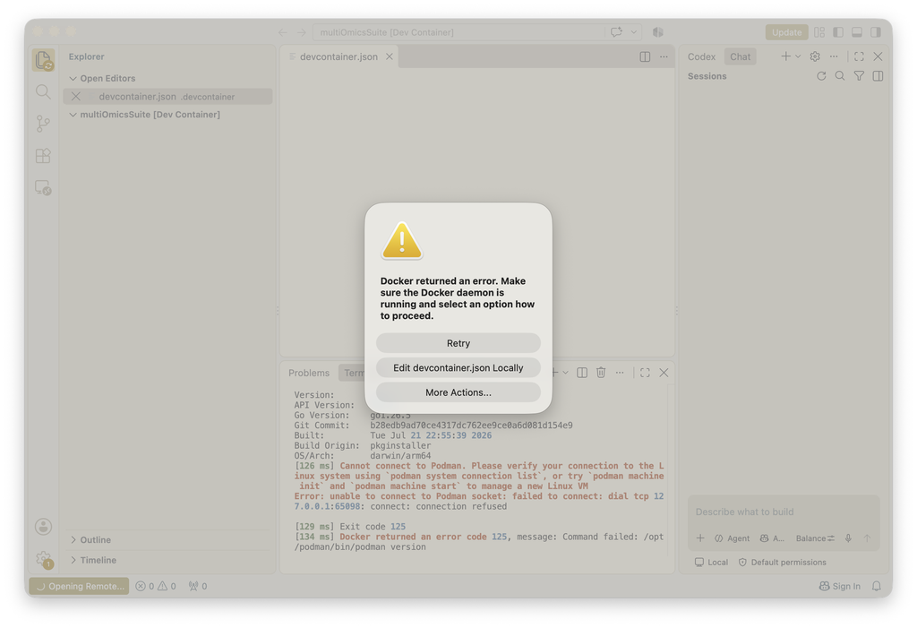

When opening the Dev Container fails instantly, make sure you started the podman machine.

## Troubleshooting

[figure not shown]

When opening the Dev Container fails instantly, make sure you started the podman machine.

## Troubleshooting: insufficient resources

If processes in the Dev Container fail due to insufficient resources (memory, disk space), increase the resources for the default podman machine and restart it.

- disk size in GB
- memory in MB

```
Terminal
```

```bash
podman machine stop
podman machine set --cpus 4 --disk-size 112 --memory 12288 --rootful=false
podman machine start
```

## Troubleshooting: when the build fails

[figure not shown]

When the container fails to be built, copy the log from the terminal.

## Troubleshooting: use agents for help

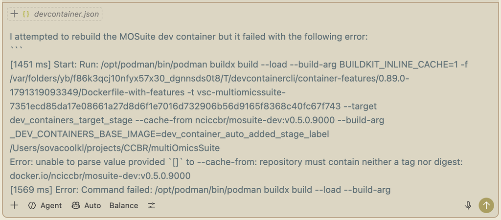

- Copy relevant parts of the log from the terminal and paste it into a *separate* window’s Copilot session.
- Do not use the same VS Code window; you’re going to want to reload the window when trying to build the container again.

## Troubleshooting: evaluate the response

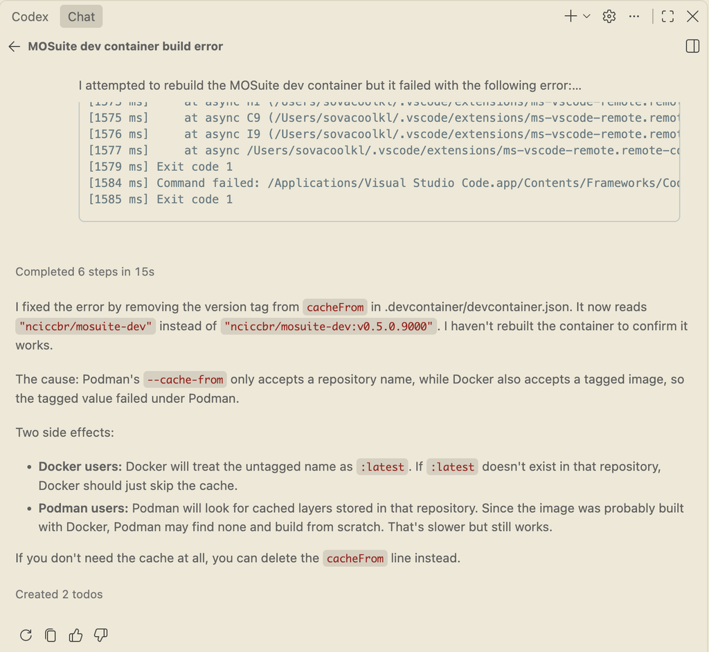

Diagnosis from Copilot:

> Podman’s –cache-from only accepts a repository name, while Docker also accepts a tagged image

## Dev Containers in VS Code on macOS

So far I’ve shown you how to get started using Dev Containers in VS Code on macOS.

- But what about other IDEs? RStudio, Positron
- Other environments? Biowulf, FRCE

## Positron

Positron supports Dev Containers!

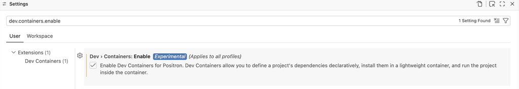

…but I haven’t gotten it to work 😿

Instructions in positron’s documentation to enable development containers: https://positron.posit.co/dev-containers.html

## Biowulf

- [You can open Dev Containers on a remote host over ssh.](https://code.visualstudio.com/docs/devcontainers/containers#_open-a-folder-on-a-remote-ssh-host-in-a-container)
- But the Dev Container extension does not yet support singularity (see [microsoft/vscode-remote-release#3066](https://github.com/microsoft/vscode-remote-release/issues/3066)).
- This will probably work if the HPC staff make podman available on biowulf in the future.

## Conclusion

#### Dev Containers have a lot of potential

- Dev Containers can help developers make their dependency management more precise and streamlined, especially when collaborating with others.
  - There is an overhead to setting up containers, but using them is fairly smooth once built.
- Security benefit: rootless containers can act as a sandbox for genAI agents to prevent them from reading/writing files in other projects.

#### Limitations prevent us from getting the most out of them right now

- Difficulties with git authentication via SSH.
- Lack of support/compatibility on Biowulf.
- Difficulties with Positron.
- GenAI is not as helpful at troubleshooting Dev Containers. Lots of red herrings.

*But these could change in the future!*

## Resources

- [Dev Containers extension for VS Code](https://code.visualstudio.com/docs/devcontainers/containers)
  - [Tutorial](https://code.visualstudio.com/docs/devcontainers/tutorial)
  - [Tips & Tricks](https://code.visualstudio.com/docs/devcontainers/tips-and-tricks)
- [The rocker project - containers for R](https://rocker-project.org/use/editor.html#visual-studio-code-dev-containers)
- [Development containers specification](https://containers.dev/)